# Using RStudio

# Learning objectives

1. To be able to identify and use the following tabs in RStudio:
- Source,
- Console,
- Environment,
- History,
- Files,
- Plots,
- Packages,
- Help,
- Viewer.
2. To be able to modify RStudio’s interface options to suit your needs.

# 1 RStudio Environment

Take note!

R is case-sensitive: That is, the name **DENGUE** in R will not be the same as **dengue** nor **Dengue** nor **denguE**. So, while using the software commands or names of objects, this should be check to avoid having errors

# 2 The RStudio panes

- By default, RStudio is arranged into four window panes as shown below.

[figure not shown]

- If you only see three panes, then this means that the source pane is missing, thus, you can click to open a new script with `File > New File > R Script` . This should reveal one more pane.

[figure not shown]

- To improve on the usability of the interface, we can rearrange these panes as much as we can.
- To do this, in the RStudio menu at the top of the screen, select `Tools > Global Options` to bring up RStudio’s options. Then under `Pane Layout`, adjust the pane arrangement. The arrangement should be af shown below.

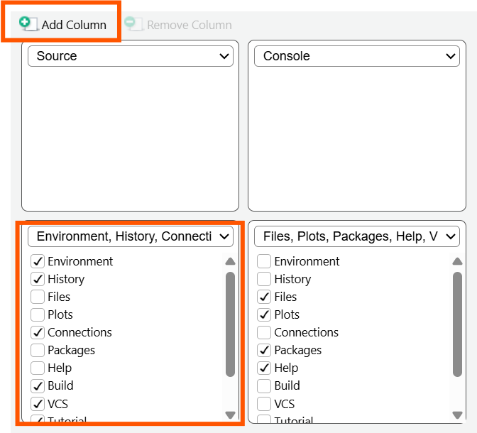

[figure not shown]

- The top-left pane is where you will do most of the coding. Make this larger by clicking on its maximize icon:

[figure not shown]

- Note that you can drag the bar that separates the window panes to resize them.

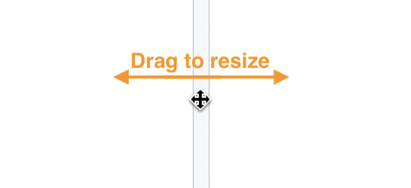

- Now let’s look at each of the RStudio tabs one by one. Below is a summary image of what we will discuss:

[figure not shown]

## 2.1 Source/Editor

[figure not shown]

```r
print("excited for R!")
print("and RStudio!")
```

- Now drag your cursor to highlight both lines and press `Command`/`Control` + `Enter`.
- To **run the entire script**, you can use `Command`/`Control` + `A` to select all code, then press `Command`/`Control` + `Enter`. Try this now. Deselect your code, then try to the shortcut to select all.

An easier way of doing this is to use the ‘Run’ button at the top right of the source panel, with which you can run code (either the current line, or all highlighted code) .

- To **open the script in a new window**, click on the third icon in the toolbar directly above the script.

[figure not shown]

- To put the window back, click on the same button on the now-external window.
- Next, **save the script.** use file-save as or just hit `Command`/`Control` + `S` to bring up the Save dialog box. Give it a file name of your choice but a meaningful name.
- If you are working with RStudio cloud, the file will be saved in your **working directory**.
- If you are working on your local computer, save the file in an easy-to-locate part of your computer, perhaps your desktop.

## 2.2 Console

- The *console*, at the bottom left (or top right), is where **code is executed**. You can type code directly here, **but it will not be saved**.
- Type a random piece of code (maybe a calculation like `10 + 4`) and press ‘Enter’.

[figure not shown]

If you place your cursor on the last line of the console, and you press the **up arrow**, you can go back to the last code that was run. Keep pressing it to cycle to the previous lines.

To run any of these previous lines, press *Enter*.

- Other tabs seen on this pane include **Terminal, Render, Background Jobs**. These are also used by R to accomplish other tasks that we will see later as we learn R.

## 2.3 Environment

- Initially, when you open RStudio, you should see at the top right of the RStudio Window, the **Environment** tab.

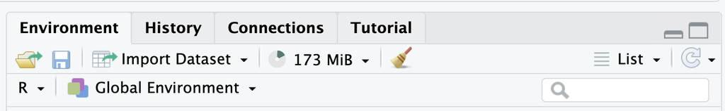

- The Environment tab shows datasets and other objects that are loaded into R’s working memory, or “workspace”.
- We will see how to explore this tab later when we will be improting datasets.